# project_kiryagina

```python
# Загружаем библиотеки
import numpy as np # работа с векторами
import matplotlib.pyplot as plt # рисовать графики
plt.style.use('ggplot')
import pandas as pd # для работы с матрицами
import os as os #для смены директории
from sklearn.model_selection import train_test_split
from sklearn.tree import  DecisionTreeClassifier
import pandas_profiling
import seaborn as sns
from sklearn.tree import export_graphviz
from sklearn import tree
from sklearn import metrics
from scipy.stats import ttest_ind
from scipy.stats import f_oneway
import statsmodels.api as sm
from statsmodels.formula.api import ols
from sklearn.preprocessing import PolynomialFeatures
from sklearn.linear_model import LogisticRegression, LogisticRegressionCV
from sklearn.model_selection import cross_val_score, StratifiedKFold
from sklearn.model_selection import GridSearchCV
from scipy import stats
from sklearn.metrics import confusion_matrix
from sklearn.metrics import classification_report
from sklearn.ensemble import RandomForestClassifier
from sklearn.ensemble import BaggingClassifier
from sklearn import model_selection
from sklearn.naive_bayes import GaussianNB
from mlxtend.classifier import StackingClassifier
import matplotlib.gridspec as gridspec
import itertools
from imblearn.over_sampling import SMOTE
from sklearn.model_selection import train_test_split
from sklearn.ensemble import GradientBoostingClassifier
import eli5
import lime
from lime.lime_tabular import LimeTabularExplainer
```

```python
bank = pd.read_csv('C:\\Users\\kirya\\Desktop\\HSE\\andan\\uci-bank-marketing\\uci-bank-marketing\\data\\bank_additional_full.csv', sep = ',')
```

### Данные

Для данного отчета был выбран датасет о маркетинговой кампании, которую проводил португальский банк. Данные взяты из этого источника https://archive.ics.uci.edu/ml/datasets/bank+marketing . Основной исследовательский вопрос заключается в том, что **необходимо предсказать, оформит ли клиент срочный вклад в банк после контактирования с ним в рамках маркетинговой кампании**.

В отчете, приведенном ниже, выведены все основные распределения по переменным, выводы из дескриптивного анализа находятся ниже.

Overview

Dataset info

| Number of variables | 21 |
| --- | --- |
| Number of observations | 41188 |
| Total Missing (%) | 0.0% |
| Total size in memory | 6.3 MiB |
| Average record size in memory | 161.0 B |

Variables types

| Numeric | 8 |
| --- | --- |
| Categorical | 10 |
| Boolean | 1 |
| Date | 0 |
| Text (Unique) | 0 |
| Rejected | 2 |
| Unsupported | 0 |

Warnings

- `euribor3m` is highly correlated with `emp_var_rate` (ρ = 0.97224) Rejected

- `nr_employed` is highly correlated with `euribor3m` (ρ = 0.94515) Rejected

- `previous` has 35563 / 86.3% zeros Zeros

- Dataset has 12 duplicate rows Warning

Variables

age  
Numeric

| Distinct count | 78 |
| --- | --- |
| Unique (%) | 0.2% |
| Missing (%) | 0.0% |
| Missing (n) | 0 |
| Infinite (%) | 0.0% |
| Infinite (n) | 0 |

| Mean | 40.024 |
| --- | --- |
| Minimum | 17 |
| Maximum | 98 |
| Zeros (%) | 0.0% |

Toggle details

**Statistics**

Quantile statistics

| Minimum | 17 |
| --- | --- |
| 5-th percentile | 26 |
| Q1 | 32 |
| Median | 38 |
| Q3 | 47 |
| 95-th percentile | 58 |
| Maximum | 98 |
| Range | 81 |
| Interquartile range | 15 |

Descriptive statistics

| Standard deviation | 10.421 |
| --- | --- |
| Coef of variation | 0.26037 |
| Kurtosis | 0.79131 |
| Mean | 40.024 |
| MAD | 8.4615 |
| Skewness | 0.7847 |
| Sum | 1648511 |
| Variance | 108.6 |
| Memory size | 321.9 KiB |

**Histogram**

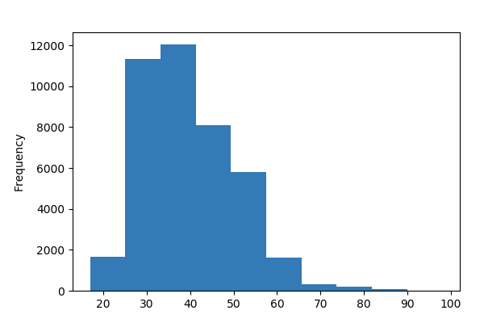

**Common Values**

| Value | Count | Frequency (%) |  |
| --- | --- | --- | --- |
| 31 | 1947 | 4.7% |  |
| 32 | 1846 | 4.5% |  |
| 33 | 1833 | 4.5% |  |
| 36 | 1780 | 4.3% |  |
| 35 | 1759 | 4.3% |  |
| 34 | 1745 | 4.2% |  |
| 30 | 1714 | 4.2% |  |
| 37 | 1475 | 3.6% |  |
| 29 | 1453 | 3.5% |  |
| 39 | 1432 | 3.5% |  |
| Other values (68) | 24204 | 58.8% |  |

**Extreme Values**

Minimum 5 values

| Value | Count | Frequency (%) |  |
| --- | --- | --- | --- |
| 17 | 5 | 0.0% |  |
| 18 | 28 | 0.1% |  |
| 19 | 42 | 0.1% |  |
| 20 | 65 | 0.2% |  |
| 21 | 102 | 0.2% |  |

Maximum 5 values

| Value | Count | Frequency (%) |  |
| --- | --- | --- | --- |
| 91 | 2 | 0.0% |  |
| 92 | 4 | 0.0% |  |
| 94 | 1 | 0.0% |  |
| 95 | 1 | 0.0% |  |
| 98 | 2 | 0.0% |  |

campaign  
Numeric

| Distinct count | 42 |
| --- | --- |
| Unique (%) | 0.1% |
| Missing (%) | 0.0% |
| Missing (n) | 0 |
| Infinite (%) | 0.0% |
| Infinite (n) | 0 |

| Mean | 2.5676 |
| --- | --- |
| Minimum | 1 |
| Maximum | 56 |
| Zeros (%) | 0.0% |

Toggle details

**Statistics**

Quantile statistics

| Minimum | 1 |
| --- | --- |
| 5-th percentile | 1 |
| Q1 | 1 |
| Median | 2 |
| Q3 | 3 |
| 95-th percentile | 7 |
| Maximum | 56 |
| Range | 55 |
| Interquartile range | 2 |

Descriptive statistics

| Standard deviation | 2.77 |
| --- | --- |
| Coef of variation | 1.0788 |
| Kurtosis | 36.98 |
| Mean | 2.5676 |
| MAD | 1.6342 |
| Skewness | 4.7625 |
| Sum | 105754 |
| Variance | 7.673 |
| Memory size | 321.9 KiB |

**Histogram**

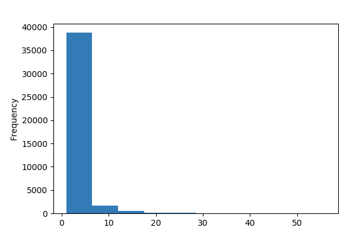

**Common Values**

| Value | Count | Frequency (%) |  |
| --- | --- | --- | --- |
| 1 | 17642 | 42.8% |  |
| 2 | 10570 | 25.7% |  |
| 3 | 5341 | 13.0% |  |
| 4 | 2651 | 6.4% |  |
| 5 | 1599 | 3.9% |  |
| 6 | 979 | 2.4% |  |
| 7 | 629 | 1.5% |  |
| 8 | 400 | 1.0% |  |
| 9 | 283 | 0.7% |  |
| 10 | 225 | 0.5% |  |
| Other values (32) | 869 | 2.1% |  |

**Extreme Values**

Minimum 5 values

| Value | Count | Frequency (%) |  |
| --- | --- | --- | --- |
| 1 | 17642 | 42.8% |  |
| 2 | 10570 | 25.7% |  |
| 3 | 5341 | 13.0% |  |
| 4 | 2651 | 6.4% |  |
| 5 | 1599 | 3.9% |  |

Maximum 5 values

| Value | Count | Frequency (%) |  |
| --- | --- | --- | --- |
| 40 | 2 | 0.0% |  |
| 41 | 1 | 0.0% |  |
| 42 | 2 | 0.0% |  |
| 43 | 2 | 0.0% |  |
| 56 | 1 | 0.0% |  |

cons_conf_idx  
Numeric

| Distinct count | 26 |
| --- | --- |
| Unique (%) | 0.1% |
| Missing (%) | 0.0% |
| Missing (n) | 0 |
| Infinite (%) | 0.0% |
| Infinite (n) | 0 |

| Mean | -40.503 |
| --- | --- |
| Minimum | -50.8 |
| Maximum | -26.9 |
| Zeros (%) | 0.0% |

Toggle details

**Statistics**

Quantile statistics

| Minimum | -50.8 |
| --- | --- |
| 5-th percentile | -47.1 |
| Q1 | -42.7 |
| Median | -41.8 |
| Q3 | -36.4 |
| 95-th percentile | -33.6 |
| Maximum | -26.9 |
| Range | 23.9 |
| Interquartile range | 6.3 |

Descriptive statistics

| Standard deviation | 4.6282 |
| --- | --- |
| Coef of variation | -0.11427 |
| Kurtosis | -0.35856 |
| Mean | -40.503 |
| MAD | 3.9383 |
| Skewness | 0.30318 |
| Sum | -1668200 |
| Variance | 21.42 |
| Memory size | 321.9 KiB |

**Histogram**

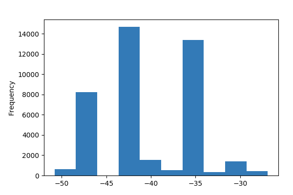

**Common Values**

| Value | Count | Frequency (%) |  |
| --- | --- | --- | --- |
| -36.4 | 7763 | 18.8% |  |
| -42.7 | 6685 | 16.2% |  |
| -46.2 | 5794 | 14.1% |  |
| -36.1 | 5175 | 12.6% |  |
| -41.8 | 4374 | 10.6% |  |
| -42.0 | 3616 | 8.8% |  |
| -47.1 | 2458 | 6.0% |  |
| -31.4 | 770 | 1.9% |  |
| -40.8 | 715 | 1.7% |  |
| -26.9 | 447 | 1.1% |  |
| Other values (16) | 3391 | 8.2% |  |

**Extreme Values**

Minimum 5 values

| Value | Count | Frequency (%) |  |
| --- | --- | --- | --- |
| -50.8 | 128 | 0.3% |  |
| -50.0 | 282 | 0.7% |  |
| -49.5 | 204 | 0.5% |  |
| -47.1 | 2458 | 6.0% |  |
| -46.2 | 5794 | 14.1% |  |

Maximum 5 values

| Value | Count | Frequency (%) |  |
| --- | --- | --- | --- |
| -33.0 | 172 | 0.4% |  |
| -31.4 | 770 | 1.9% |  |
| -30.1 | 357 | 0.9% |  |
| -29.8 | 267 | 0.6% |  |
| -26.9 | 447 | 1.1% |  |

cons_price_idx  
Numeric

| Distinct count | 26 |
| --- | --- |
| Unique (%) | 0.1% |
| Missing (%) | 0.0% |
| Missing (n) | 0 |
| Infinite (%) | 0.0% |
| Infinite (n) | 0 |

| Mean | 93.576 |
| --- | --- |
| Minimum | 92.201 |
| Maximum | 94.767 |
| Zeros (%) | 0.0% |

Toggle details

**Statistics**

Quantile statistics

| Minimum | 92.201 |
| --- | --- |
| 5-th percentile | 92.713 |
| Q1 | 93.075 |
| Median | 93.749 |
| Q3 | 93.994 |
| 95-th percentile | 94.465 |
| Maximum | 94.767 |
| Range | 2.566 |
| Interquartile range | 0.919 |

Descriptive statistics

| Standard deviation | 0.57884 |
| --- | --- |
| Coef of variation | 0.0061858 |
| Kurtosis | -0.82981 |
| Mean | 93.576 |
| MAD | 0.50981 |
| Skewness | -0.23089 |
| Sum | 3854200 |
| Variance | 0.33506 |
| Memory size | 321.9 KiB |

**Histogram**

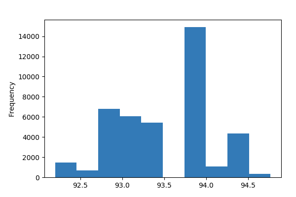

**Common Values**

| Value | Count | Frequency (%) |  |
| --- | --- | --- | --- |
| 93.994 | 7763 | 18.8% |  |
| 93.91799999999999 | 6685 | 16.2% |  |
| 92.89299999999999 | 5794 | 14.1% |  |
| 93.444 | 5175 | 12.6% |  |
| 94.465 | 4374 | 10.6% |  |
| 93.2 | 3616 | 8.8% |  |
| 93.075 | 2458 | 6.0% |  |
| 92.20100000000001 | 770 | 1.9% |  |
| 92.963 | 715 | 1.7% |  |
| 92.431 | 447 | 1.1% |  |
| Other values (16) | 3391 | 8.2% |  |

**Extreme Values**

Minimum 5 values

| Value | Count | Frequency (%) |  |
| --- | --- | --- | --- |
| 92.20100000000001 | 770 | 1.9% |  |
| 92.37899999999999 | 267 | 0.6% |  |
| 92.431 | 447 | 1.1% |  |
| 92.469 | 178 | 0.4% |  |
| 92.649 | 357 | 0.9% |  |

Maximum 5 values

| Value | Count | Frequency (%) |  |
| --- | --- | --- | --- |
| 94.199 | 303 | 0.7% |  |
| 94.215 | 311 | 0.8% |  |
| 94.465 | 4374 | 10.6% |  |
| 94.601 | 204 | 0.5% |  |
| 94.76700000000001 | 128 | 0.3% |  |

contact  
Categorical

| Distinct count | 2 |
| --- | --- |
| Unique (%) | 0.0% |
| Missing (%) | 0.0% |
| Missing (n) | 0 |

| cellular | 26144 |
| --- | --- |
| telephone | 15044 |

Toggle details

| Value | Count | Frequency (%) |  |
| --- | --- | --- | --- |
| cellular | 26144 | 63.5% |  |
| telephone | 15044 | 36.5% |  |

day_of_week  
Categorical

| Distinct count | 5 |
| --- | --- |
| Unique (%) | 0.0% |
| Missing (%) | 0.0% |
| Missing (n) | 0 |

| thu | 8623 |
| --- | --- |
| mon | 8514 |
| wed | 8134 |
| Other values (2) | 15917 |

Toggle details

| Value | Count | Frequency (%) |  |
| --- | --- | --- | --- |
| thu | 8623 | 20.9% |  |
| mon | 8514 | 20.7% |  |
| wed | 8134 | 19.7% |  |
| tue | 8090 | 19.6% |  |
| fri | 7827 | 19.0% |  |

default  
Categorical

| Distinct count | 3 |
| --- | --- |
| Unique (%) | 0.0% |
| Missing (%) | 0.0% |
| Missing (n) | 0 |

| no | 32588 |
| --- | --- |
| unknown | 8597 |
| yes | 3 |

Toggle details

| Value | Count | Frequency (%) |  |
| --- | --- | --- | --- |
| no | 32588 | 79.1% |  |
| unknown | 8597 | 20.9% |  |
| yes | 3 | 0.0% |  |

duration  
Numeric

| Distinct count | 1544 |
| --- | --- |
| Unique (%) | 3.7% |
| Missing (%) | 0.0% |
| Missing (n) | 0 |
| Infinite (%) | 0.0% |
| Infinite (n) | 0 |

| Mean | 258.29 |
| --- | --- |
| Minimum | 0 |
| Maximum | 4918 |
| Zeros (%) | 0.0% |

Toggle details

**Statistics**

Quantile statistics

| Minimum | 0 |
| --- | --- |
| 5-th percentile | 36 |
| Q1 | 102 |
| Median | 180 |
| Q3 | 319 |
| 95-th percentile | 752.65 |
| Maximum | 4918 |
| Range | 4918 |
| Interquartile range | 217 |

Descriptive statistics

| Standard deviation | 259.28 |
| --- | --- |
| Coef of variation | 1.0038 |
| Kurtosis | 20.248 |
| Mean | 258.29 |
| MAD | 171.67 |
| Skewness | 3.2631 |
| Sum | 10638243 |
| Variance | 67226 |
| Memory size | 321.9 KiB |

**Histogram**

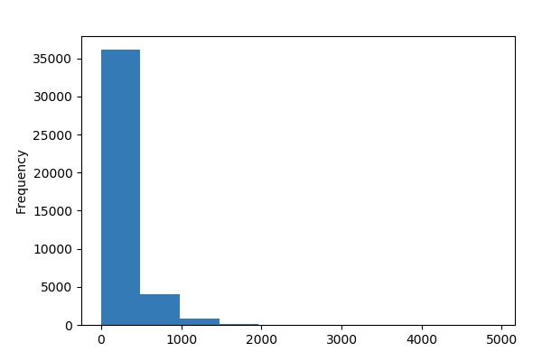

**Common Values**

| Value | Count | Frequency (%) |  |
| --- | --- | --- | --- |
| 85 | 170 | 0.4% |  |
| 90 | 170 | 0.4% |  |
| 136 | 168 | 0.4% |  |
| 73 | 167 | 0.4% |  |
| 124 | 164 | 0.4% |  |
| 87 | 162 | 0.4% |  |
| 72 | 161 | 0.4% |  |
| 104 | 161 | 0.4% |  |
| 111 | 160 | 0.4% |  |
| 106 | 159 | 0.4% |  |
| Other values (1534) | 39546 | 96.0% |  |

**Extreme Values**

Minimum 5 values

| Value | Count | Frequency (%) |  |
| --- | --- | --- | --- |
| 0 | 4 | 0.0% |  |
| 1 | 3 | 0.0% |  |
| 2 | 1 | 0.0% |  |
| 3 | 3 | 0.0% |  |
| 4 | 12 | 0.0% |  |

Maximum 5 values

| Value | Count | Frequency (%) |  |
| --- | --- | --- | --- |
| 3631 | 1 | 0.0% |  |
| 3643 | 1 | 0.0% |  |
| 3785 | 1 | 0.0% |  |
| 4199 | 1 | 0.0% |  |
| 4918 | 1 | 0.0% |  |

education  
Categorical

| Distinct count | 8 |
| --- | --- |
| Unique (%) | 0.0% |
| Missing (%) | 0.0% |
| Missing (n) | 0 |

| university.degree | 12168 |
| --- | --- |
| high.school | 9515 |
| basic.9y | 6045 |
| Other values (5) | 13460 |

Toggle details

| Value | Count | Frequency (%) |  |
| --- | --- | --- | --- |
| university.degree | 12168 | 29.5% |  |
| high.school | 9515 | 23.1% |  |
| basic.9y | 6045 | 14.7% |  |
| professional.course | 5243 | 12.7% |  |
| basic.4y | 4176 | 10.1% |  |
| basic.6y | 2292 | 5.6% |  |
| unknown | 1731 | 4.2% |  |
| illiterate | 18 | 0.0% |  |

emp_var_rate  
Numeric

| Distinct count | 10 |
| --- | --- |
| Unique (%) | 0.0% |
| Missing (%) | 0.0% |
| Missing (n) | 0 |
| Infinite (%) | 0.0% |
| Infinite (n) | 0 |

| Mean | 0.081886 |
| --- | --- |
| Minimum | -3.4 |
| Maximum | 1.4 |
| Zeros (%) | 0.0% |

Toggle details

**Statistics**

Quantile statistics

| Minimum | -3.4 |
| --- | --- |
| 5-th percentile | -2.9 |
| Q1 | -1.8 |
| Median | 1.1 |
| Q3 | 1.4 |
| 95-th percentile | 1.4 |
| Maximum | 1.4 |
| Range | 4.8 |
| Interquartile range | 3.2 |

Descriptive statistics

| Standard deviation | 1.571 |
| --- | --- |
| Coef of variation | 19.185 |
| Kurtosis | -1.0626 |
| Mean | 0.081886 |
| MAD | 1.4228 |
| Skewness | -0.7241 |
| Sum | 3372.7 |
| Variance | 2.4679 |
| Memory size | 321.9 KiB |

**Histogram**

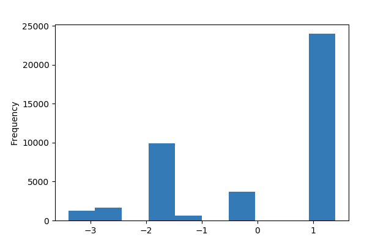

**Common Values**

| Value | Count | Frequency (%) |  |
| --- | --- | --- | --- |
| 1.4 | 16234 | 39.4% |  |
| -1.8 | 9184 | 22.3% |  |
| 1.1 | 7763 | 18.8% |  |
| -0.1 | 3683 | 8.9% |  |
| -2.9 | 1663 | 4.0% |  |
| -3.4 | 1071 | 2.6% |  |
| -1.7 | 773 | 1.9% |  |
| -1.1 | 635 | 1.5% |  |
| -3.0 | 172 | 0.4% |  |
| -0.2 | 10 | 0.0% |  |

**Extreme Values**

Minimum 5 values

| Value | Count | Frequency (%) |  |
| --- | --- | --- | --- |
| -3.4 | 1071 | 2.6% |  |
| -3.0 | 172 | 0.4% |  |
| -2.9 | 1663 | 4.0% |  |
| -1.8 | 9184 | 22.3% |  |
| -1.7 | 773 | 1.9% |  |

Maximum 5 values

| Value | Count | Frequency (%) |  |
| --- | --- | --- | --- |
| -1.1 | 635 | 1.5% |  |
| -0.2 | 10 | 0.0% |  |
| -0.1 | 3683 | 8.9% |  |
| 1.1 | 7763 | 18.8% |  |
| 1.4 | 16234 | 39.4% |  |

euribor3m  
Highly correlated

*This variable is highly correlated with `emp_var_rate` and should be ignored for analysis*

| Correlation | 0.97224 |
| --- | --- |

housing  
Categorical

| Distinct count | 3 |
| --- | --- |
| Unique (%) | 0.0% |
| Missing (%) | 0.0% |
| Missing (n) | 0 |

| yes | 21576 |
| --- | --- |
| no | 18622 |
| unknown | 990 |

Toggle details

| Value | Count | Frequency (%) |  |
| --- | --- | --- | --- |
| yes | 21576 | 52.4% |  |
| no | 18622 | 45.2% |  |
| unknown | 990 | 2.4% |  |

job  
Categorical

| Distinct count | 12 |
| --- | --- |
| Unique (%) | 0.0% |
| Missing (%) | 0.0% |
| Missing (n) | 0 |

| admin. | 10422 |
| --- | --- |
| blue-collar | 9254 |
| technician | 6743 |
| Other values (9) | 14769 |

Toggle details

| Value | Count | Frequency (%) |  |
| --- | --- | --- | --- |
| admin. | 10422 | 25.3% |  |
| blue-collar | 9254 | 22.5% |  |
| technician | 6743 | 16.4% |  |
| services | 3969 | 9.6% |  |
| management | 2924 | 7.1% |  |
| retired | 1720 | 4.2% |  |
| entrepreneur | 1456 | 3.5% |  |
| self-employed | 1421 | 3.5% |  |
| housemaid | 1060 | 2.6% |  |
| unemployed | 1014 | 2.5% |  |
| Other values (2) | 1205 | 2.9% |  |

loan  
Categorical

| Distinct count | 3 |
| --- | --- |
| Unique (%) | 0.0% |
| Missing (%) | 0.0% |
| Missing (n) | 0 |

| no | 33950 |
| --- | --- |
| yes | 6248 |
| unknown | 990 |

Toggle details

| Value | Count | Frequency (%) |  |
| --- | --- | --- | --- |
| no | 33950 | 82.4% |  |
| yes | 6248 | 15.2% |  |
| unknown | 990 | 2.4% |  |

marital  
Categorical

| Distinct count | 4 |
| --- | --- |
| Unique (%) | 0.0% |
| Missing (%) | 0.0% |
| Missing (n) | 0 |

| married | 24928 |
| --- | --- |
| single | 11568 |
| divorced | 4612 |

Toggle details

| Value | Count | Frequency (%) |  |
| --- | --- | --- | --- |
| married | 24928 | 60.5% |  |
| single | 11568 | 28.1% |  |
| divorced | 4612 | 11.2% |  |
| unknown | 80 | 0.2% |  |

month  
Categorical

| Distinct count | 10 |
| --- | --- |
| Unique (%) | 0.0% |
| Missing (%) | 0.0% |
| Missing (n) | 0 |

| may | 13769 |
| --- | --- |
| jul | 7174 |
| aug | 6178 |
| Other values (7) | 14067 |

Toggle details

| Value | Count | Frequency (%) |  |
| --- | --- | --- | --- |
| may | 13769 | 33.4% |  |
| jul | 7174 | 17.4% |  |
| aug | 6178 | 15.0% |  |
| jun | 5318 | 12.9% |  |
| nov | 4101 | 10.0% |  |
| apr | 2632 | 6.4% |  |
| oct | 718 | 1.7% |  |
| sep | 570 | 1.4% |  |
| mar | 546 | 1.3% |  |
| dec | 182 | 0.4% |  |

nr_employed  
Highly correlated

*This variable is highly correlated with `euribor3m` and should be ignored for analysis*

| Correlation | 0.94515 |
| --- | --- |

pdays  
Numeric

| Distinct count | 27 |
| --- | --- |
| Unique (%) | 0.1% |
| Missing (%) | 0.0% |
| Missing (n) | 0 |
| Infinite (%) | 0.0% |
| Infinite (n) | 0 |

| Mean | 962.48 |
| --- | --- |
| Minimum | 0 |
| Maximum | 999 |
| Zeros (%) | 0.0% |

Toggle details

**Statistics**

Quantile statistics

| Minimum | 0 |
| --- | --- |
| 5-th percentile | 999 |
| Q1 | 999 |
| Median | 999 |
| Q3 | 999 |
| 95-th percentile | 999 |
| Maximum | 999 |
| Range | 999 |
| Interquartile range | 0 |

Descriptive statistics

| Standard deviation | 186.91 |
| --- | --- |
| Coef of variation | 0.1942 |
| Kurtosis | 22.229 |
| Mean | 962.48 |
| MAD | 70.362 |
| Skewness | -4.9222 |
| Sum | 39642439 |
| Variance | 34936 |
| Memory size | 321.9 KiB |

**Histogram**

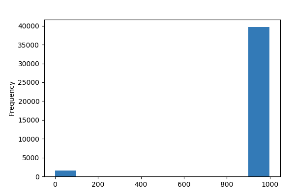

**Common Values**

| Value | Count | Frequency (%) |  |
| --- | --- | --- | --- |
| 999 | 39673 | 96.3% |  |
| 3 | 439 | 1.1% |  |
| 6 | 412 | 1.0% |  |
| 4 | 118 | 0.3% |  |
| 9 | 64 | 0.2% |  |
| 2 | 61 | 0.1% |  |
| 7 | 60 | 0.1% |  |
| 12 | 58 | 0.1% |  |
| 10 | 52 | 0.1% |  |
| 5 | 46 | 0.1% |  |
| Other values (17) | 205 | 0.5% |  |

**Extreme Values**

Minimum 5 values

| Value | Count | Frequency (%) |  |
| --- | --- | --- | --- |
| 0 | 15 | 0.0% |  |
| 1 | 26 | 0.1% |  |
| 2 | 61 | 0.1% |  |
| 3 | 439 | 1.1% |  |
| 4 | 118 | 0.3% |  |

Maximum 5 values

| Value | Count | Frequency (%) |  |
| --- | --- | --- | --- |
| 22 | 3 | 0.0% |  |
| 25 | 1 | 0.0% |  |
| 26 | 1 | 0.0% |  |
| 27 | 1 | 0.0% |  |
| 999 | 39673 | 96.3% |  |

poutcome  
Categorical

| Distinct count | 3 |
| --- | --- |
| Unique (%) | 0.0% |
| Missing (%) | 0.0% |
| Missing (n) | 0 |

| nonexistent | 35563 |
| --- | --- |
| failure | 4252 |
| success | 1373 |

Toggle details

| Value | Count | Frequency (%) |  |
| --- | --- | --- | --- |
| nonexistent | 35563 | 86.3% |  |
| failure | 4252 | 10.3% |  |
| success | 1373 | 3.3% |  |

previous  
Numeric

| Distinct count | 8 |
| --- | --- |
| Unique (%) | 0.0% |
| Missing (%) | 0.0% |
| Missing (n) | 0 |
| Infinite (%) | 0.0% |
| Infinite (n) | 0 |

| Mean | 0.17296 |
| --- | --- |
| Minimum | 0 |
| Maximum | 7 |
| Zeros (%) | 86.3% |

Toggle details

**Statistics**

Quantile statistics

| Minimum | 0 |
| --- | --- |
| 5-th percentile | 0 |
| Q1 | 0 |
| Median | 0 |
| Q3 | 0 |
| 95-th percentile | 1 |
| Maximum | 7 |
| Range | 7 |
| Interquartile range | 0 |

Descriptive statistics

| Standard deviation | 0.4949 |
| --- | --- |
| Coef of variation | 2.8613 |
| Kurtosis | 20.109 |
| Mean | 0.17296 |
| MAD | 0.29868 |
| Skewness | 3.832 |
| Sum | 7124 |
| Variance | 0.24493 |
| Memory size | 321.9 KiB |

**Histogram**

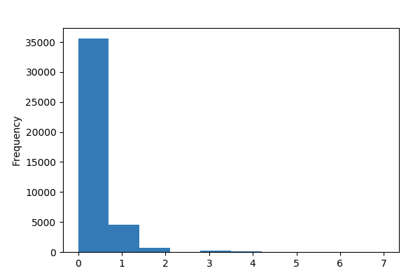

**Common Values**

| Value | Count | Frequency (%) |  |
| --- | --- | --- | --- |
| 0 | 35563 | 86.3% |  |
| 1 | 4561 | 11.1% |  |
| 2 | 754 | 1.8% |  |
| 3 | 216 | 0.5% |  |
| 4 | 70 | 0.2% |  |
| 5 | 18 | 0.0% |  |
| 6 | 5 | 0.0% |  |
| 7 | 1 | 0.0% |  |

**Extreme Values**

Minimum 5 values

| Value | Count | Frequency (%) |  |
| --- | --- | --- | --- |
| 0 | 35563 | 86.3% |  |
| 1 | 4561 | 11.1% |  |
| 2 | 754 | 1.8% |  |
| 3 | 216 | 0.5% |  |
| 4 | 70 | 0.2% |  |

Maximum 5 values

| Value | Count | Frequency (%) |  |
| --- | --- | --- | --- |
| 3 | 216 | 0.5% |  |
| 4 | 70 | 0.2% |  |
| 5 | 18 | 0.0% |  |
| 6 | 5 | 0.0% |  |
| 7 | 1 | 0.0% |  |

y  
Boolean

| Distinct count | 2 |
| --- | --- |
| Unique (%) | 0.0% |
| Missing (%) | 0.0% |
| Missing (n) | 0 |

| Mean | 0.11265 |
| --- | --- |

| True | 4640 |
| --- | --- |
| (Missing) | 36548 |

Toggle details

| Value | Count | Frequency (%) |  |
| --- | --- | --- | --- |
| True | 4640 | 11.3% |  |
| (Missing) | 36548 | 88.7% |  |

Correlations

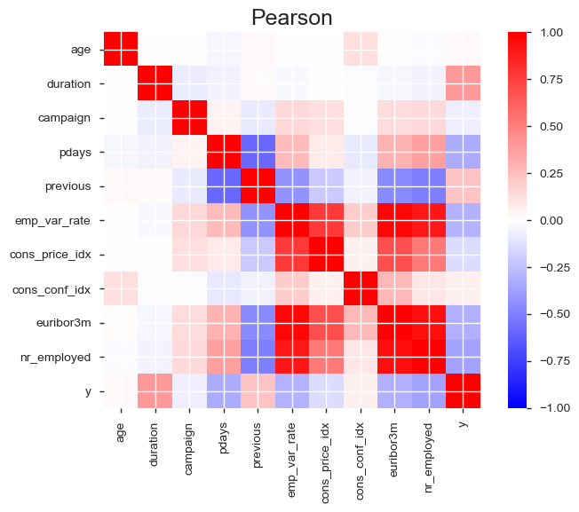

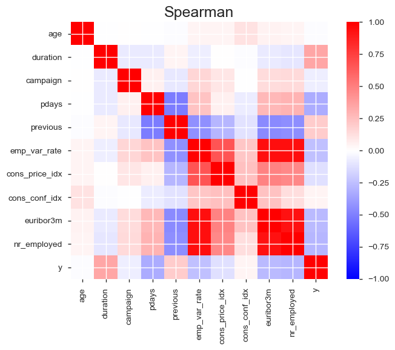

Sample

|  | age | job | marital | education | default | housing | loan | contact | month | day_of_week | duration | campaign | pdays | previous | poutcome | emp_var_rate | cons_price_idx | cons_conf_idx | euribor3m | nr_employed | y |
| --- | --- | --- | --- | --- | --- | --- | --- | --- | --- | --- | --- | --- | --- | --- | --- | --- | --- | --- | --- | --- | --- |
| 0 | 56 | housemaid | married | basic.4y | no | no | no | telephone | may | mon | 261 | 1 | 999 | 0 | nonexistent | 1.1 | 93.994 | -36.4 | 4.857 | 5191.0 | False |
| 1 | 57 | services | married | high.school | unknown | no | no | telephone | may | mon | 149 | 1 | 999 | 0 | nonexistent | 1.1 | 93.994 | -36.4 | 4.857 | 5191.0 | False |
| 2 | 37 | services | married | high.school | no | yes | no | telephone | may | mon | 226 | 1 | 999 | 0 | nonexistent | 1.1 | 93.994 | -36.4 | 4.857 | 5191.0 | False |
| 3 | 40 | admin. | married | basic.6y | no | no | no | telephone | may | mon | 151 | 1 | 999 | 0 | nonexistent | 1.1 | 93.994 | -36.4 | 4.857 | 5191.0 | False |
| 4 | 56 | services | married | high.school | no | no | yes | telephone | may | mon | 307 | 1 | 999 | 0 | nonexistent | 1.1 | 93.994 | -36.4 | 4.857 | 5191.0 | False |

```python
pandas_profiling.ProfileReport(bank)
```

Видим, что в нашей выборке 21 переменная, где "у" наша целевая переменная, принимающая два значения (true - оформит вклад or false - не оформит вклад).

Среди трех макроэкономичеких переменных (euribor3m, nr_employedб, emp_var_rate) наблюдаем сильную корреляцию, поэтому было решено оставить переменную emp_var_rate, значения которой относительно уже сконцентрированы в районе 0, что позволит избежать эффекта больших значений переменной на результаты.

Также было решено исключить из рассмотрения переменную duration, которая имеет сильную зависимость с исходом, а также pdays и previous.

Наблюдаем относительно равномерно распределение среди дней недели, однако неравномерное среди месяцев, что позволяет сделать предположение о том, что месяц имеет значимое влияние на исход кампании для отдельного клиента.

После исследования данных, было решено оставить следующий набор переменных для последующего анализа. Переменные можно разделить на 3 категории:

Данные о клиенте:

- возраст
- отрасль занятости
- семейный статус
- уровень образования
- наличие ипотеки
- наличие ссуды

Данные о связи с клиентом во время кампании:

- тип связи (телефон, мобильная связь)
- месяц, в котором был совершен последний контакт с клиентом в течении кампании
- день недели, в котором был совершен последний контакт с клиентом в течении кампании
- количество контактов с клиентом, которые были совершены в течении кампании
- исход предыдущей маркетинговой кампании

Макроэкономические показатели:

- относительный показатель уровня занятости
- индекс потребительских цен
- индекс доверия потребителей

Далее мы рассмотрим модель классификации, которая была выбрана в качестве итоговой для ответа на вопрос, оформит клиент вклад или не оформит.

### Небольшой препроцессинг

Удалим некоторые переменные

```python
bank = bank.drop(columns = ['default', 'duration', 'pdays', 'previous', 'nr_employed', 'euribor3m']);
```

Для корректной работы алгоритмов необходимо перевести категориальные переменные в дамми, затем исключив одну категорию из каждой группы, чтобы переменные не были линейно зависимы.

```python
bank['job'] = bank['job'].astype('category')
bank['marital'] = bank['marital'].astype('category')
bank['education'] = bank['education'].astype('category')
bank['housing'] = bank['housing'].astype('category')
bank['loan'] = bank['loan'].astype('category')
bank['contact'] = bank['contact'].astype('category')
bank['month'] = bank['month'].astype('category')
bank['day_of_week'] = bank['day_of_week'].astype('category')
bank['poutcome'] = bank['poutcome'].astype('category')
```

```python
cat_vars=['job','marital','education','housing','loan','contact','month','day_of_week','poutcome']
for var in cat_vars:
    cat_list='var'+'_'+var
    cat_list = pd.get_dummies(bank[var], drop_first=True, prefix=var)
    bank1=bank.join(cat_list)
    bank=bank1
cat_vars=['job','marital','education','housing','loan','contact','month','day_of_week','poutcome']
bank_vars=bank.columns.values.tolist()
to_keep=[i for i in bank_vars if i not in cat_vars]
```

```python
bank_final=bank[to_keep]
bank_final.columns.values;
```

Зададим целевую переменную и объясняющие.

```python
X = bank.loc[:,['age', 'campaign', 'emp_var_rate', 'cons_price_idx',
       'cons_conf_idx', 'job_blue-collar', 'job_entrepreneur',
       'job_housemaid', 'job_management', 'job_retired',
       'job_self-employed', 'job_services', 'job_student',
       'job_technician', 'job_unemployed', 'job_unknown',
       'marital_married', 'marital_single', 'marital_unknown',
       'education_basic.6y', 'education_basic.9y',
       'education_high.school', 'education_illiterate',
       'education_professional.course', 'education_university.degree',
       'education_unknown', 'housing_unknown', 'housing_yes',
       'loan_unknown', 'loan_yes', 'contact_telephone', 'month_aug',
       'month_dec', 'month_jul', 'month_jun', 'month_mar', 'month_may',
       'month_nov', 'month_oct', 'month_sep', 'day_of_week_mon',
       'day_of_week_thu', 'day_of_week_tue', 'day_of_week_wed',
       'poutcome_nonexistent', 'poutcome_success']]
y = bank['y']
```

Разобьем нашу выборку на обучающую и тестовую.

Однако в данном датасете присутствует имбаланс классов целевой переменной. Необходимо избавиться от него с помощью SMOTE алгоритма, который уравняет в обучающей выборке соотношение классов.

```python
X_train, X_test, y_train, y_test = train_test_split(X, y, test_size=0.25, random_state=11333)

print("Размерность обучающей выборки X: ", X_train.shape)
print("Размерность обучающие выборки у: ", y_train.shape)
print("Размерность тестовой выборки Х: ", X_test.shape)
print("Размерность тестовой выборки у: ", y_test.shape)

print("До уравнивания количество класса '1': {}".format(sum(y_train==1)))
print("До уравнивания количество класса '0': {} \n".format(sum(y_train==0)))

sm = SMOTE(random_state=11333)
X_train_res, y_train_res = sm.fit_sample(X_train, y_train)

print('После уравнивания классов обучающая Х: {}'.format(X_train_res.shape))
print('После уравнивания классов обучающая y: {} \n'.format(y_train_res.shape))
print("После уравнивания количество класса '1': {}".format(sum(y_train_res==1)))
print("После уравнивания количество класса '0': {}".format(sum(y_train_res==0)))
```

```
Размерность обучающей выборки X:  (30891, 46)
Размерность обучающие выборки у:  (30891,)
Размерность тестовой выборки Х:  (10297, 46)
Размерность тестовой выборки у:  (10297,)
До уравнивания количество класса '1': 3468
До уравнивания количество класса '0': 27423

После уравнивания классов обучающая Х: (54846, 46)
После уравнивания классов обучающая y: (54846,)

После уравнивания количество класса '1': 27423
После уравнивания количество класса '0': 27423
```

### Модель

Для классификации в качестве итоговой модели был выбран градиентный бустинг, который показал наилучшее качество.

```python
modelGB = GradientBoostingClassifier(n_estimators=150)
modelGB.fit(X_train_res, y_train_res)
print("Доля правильных ответов классификатора на обучающей выборке:",
      round(modelGB.score(X_train_res, y_train_res), 3))
print("Доля правильных ответов классификатора на тестовой выборке:",
      round(modelGB.score(X_test, y_test), 3))
```

```
Доля правильных ответов классификатора на обучающей выборке: 0.935
Доля правильных ответов классификатора на тестовой выборке: 0.893
```

### Интерпретация

Выясним, какие переменные имеют наибольший вклад в результат.

```python
names = ['age', 'campaign', 'emp_var_rate', 'cons_price_idx',
       'cons_conf_idx', 'job_blue-collar', 'job_entrepreneur',
       'job_housemaid', 'job_management', 'job_retired',
       'job_self-employed', 'job_services', 'job_student',
       'job_technician', 'job_unemployed', 'job_unknown',
       'marital_married', 'marital_single', 'marital_unknown',
       'education_basic.6y', 'education_basic.9y',
       'education_high.school', 'education_illiterate',
       'education_professional.course', 'education_university.degree',
       'education_unknown', 'housing_unknown', 'housing_yes',
       'loan_unknown', 'loan_yes', 'contact_telephone', 'month_aug',
       'month_dec', 'month_jul', 'month_jun', 'month_mar', 'month_may',
       'month_nov', 'month_oct', 'month_sep', 'day_of_week_mon',
       'day_of_week_thu', 'day_of_week_tue', 'day_of_week_wed',
       'poutcome_nonexistent', 'poutcome_success']
eli5.explain_weights_df(modelGB, feature_names = names)
```

|  | feature | weight | std |
| --- | --- | --- | --- |
| 0 | campaign | 0.081029 | 0.227314 |
| 1 | emp_var_rate | 0.064244 | 0.111884 |
| 2 | housing_yes | 0.063628 | 0.182382 |
| 3 | marital_married | 0.047325 | 0.148782 |
| 4 | poutcome_success | 0.047266 | 0.056255 |
| 5 | loan_yes | 0.046485 | 0.159908 |
| 6 | day_of_week_wed | 0.041119 | 0.141098 |
| 7 | day_of_week_tue | 0.038125 | 0.133747 |
| 8 | day_of_week_thu | 0.038057 | 0.130749 |
| 9 | day_of_week_mon | 0.036872 | 0.122523 |
| 10 | poutcome_nonexistent | 0.036039 | 0.094521 |
| 11 | job_technician | 0.035762 | 0.149218 |
| 12 | job_blue-collar | 0.033159 | 0.119769 |
| 13 | education_high.school | 0.031978 | 0.133852 |
| 14 | cons_conf_idx | 0.030241 | 0.055385 |
| 15 | job_services | 0.029596 | 0.129580 |
| 16 | education_basic.9y | 0.029049 | 0.114881 |
| 17 | job_management | 0.026672 | 0.128340 |
| 18 | contact_telephone | 0.026595 | 0.111868 |
| 19 | education_university.degree | 0.023902 | 0.100216 |
| 20 | month_may | 0.020248 | 0.053423 |
| 21 | cons_price_idx | 0.019538 | 0.046759 |
| 22 | job_entrepreneur | 0.018922 | 0.108042 |
| 23 | education_professional.course | 0.018799 | 0.107590 |
| 24 | age | 0.018276 | 0.039955 |
| 25 | job_unemployed | 0.014485 | 0.087583 |
| 26 | education_basic.6y | 0.013960 | 0.063209 |
| 27 | job_self-employed | 0.013945 | 0.073070 |
| 28 | marital_single | 0.011323 | 0.050612 |
| 29 | job_housemaid | 0.010797 | 0.075607 |
| 30 | education_unknown | 0.007088 | 0.048748 |
| 31 | month_oct | 0.006650 | 0.028585 |
| 32 | month_mar | 0.005271 | 0.020844 |
| 33 | month_aug | 0.003400 | 0.025229 |
| 34 | marital_unknown | 0.002521 | 0.012120 |
| 35 | loan_unknown | 0.001583 | 0.013727 |
| 36 | month_jul | 0.001281 | 0.012997 |
| 37 | month_nov | 0.000872 | 0.007029 |
| 38 | month_dec | 0.000843 | 0.005902 |
| 39 | job_student | 0.000801 | 0.007010 |
| 40 | month_sep | 0.000791 | 0.005901 |
| 41 | housing_unknown | 0.000692 | 0.008453 |
| 42 | job_unknown | 0.000340 | 0.003195 |
| 43 | job_retired | 0.000228 | 0.002787 |
| 44 | month_jun | 0.000203 | 0.002484 |
| 45 | education_illiterate | 0.000000 | 0.000000 |

Видим, что количество контактов с клиентом (campaign) имеет весомый вклад, а также показатель уровня занятости (emp_var_rate), наличие ипотеки (housing), семейный статус "в браке" (marital_married), успешный исход предыдущей кампании (poutcome).

Выявим на конкретном примере, как переменные влияют на результат. Для этого выберем, напрмер, пример со статусом "в браке" и отрицательным исходом.

```python
exp = explainer.explain_instance(X_test.values[1,:],
                                 modelGB.predict_proba)
```

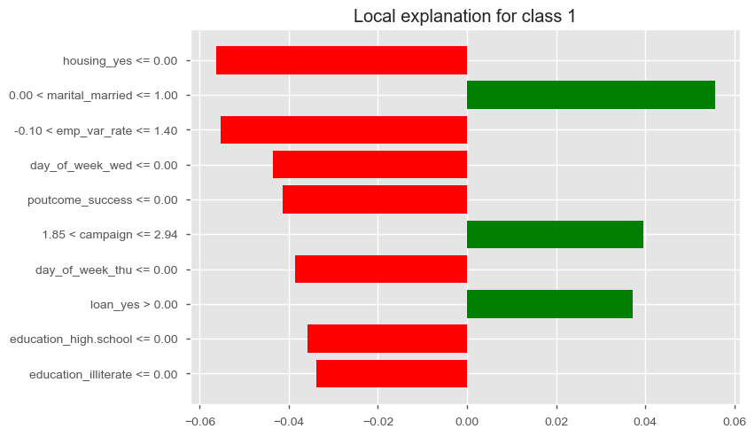

```python
exp.as_pyplot_figure();
```

Заметим, что статус "в браке" вносит положительный вклад в то, что клиент оформит вклад. Количество звонков примерно 2 за кампанию тоже повышает вероятность клиента оформить вклад, вместе с наличием займа в этом банке.

Возьмем пример с тем же статусом "в браке" только с положительным исходом.

```python
df = pd.concat([X_test, y_test], axis=1)
df[(df['marital_married']==1) & (df['y']==True)]
X_test.loc[15317, :];
```

```python
exp = explainer.explain_instance(X_test.loc[15317, :],
                                 modelGB.predict_proba)
```

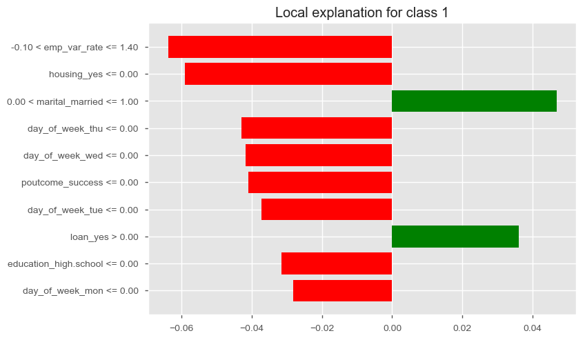

```python
exp.as_pyplot_figure();
```

Заметим, что статус "в браке" все также увеличивает вероятность оформить вклад. А показатель уровня занятости от -0.10 до 1.40 снижает вероятность клиентов оформлять вклад.

Теперь обратим внимание на переменную успешного исхода предыдущей кампании.

```python
X_test['poutcome_success']==1;
```

```python
exp = explainer.explain_instance(X_test.loc[41089, :],
                                 modelGB.predict_proba)
```

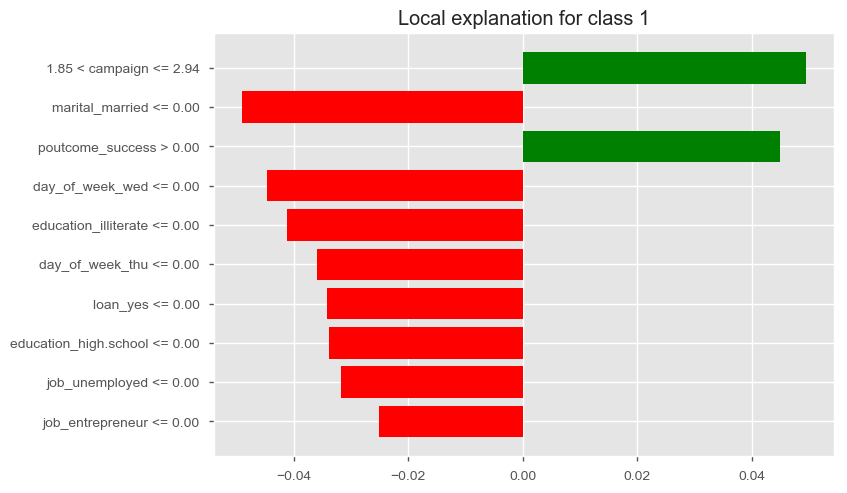

```python
exp.as_pyplot_figure();
```

Заметим, что статус "не в браке" понижает вероятность оформить вклад, а успешный исход предыдущей кампании увеличивает вероятность оформить вклад. Также подтверждается суждение о том, что количество звонков равное 2 в течении компании тоже повышает вероятность оформить вклад.

### Практические выводы

- Количество контактов с клиентом равное 2 в течении кампании увеличивает вероятность оформить вклад.
- Статут "в браке" увеличивает вероятность оформить вклад
- Успешный исход предыдущей компании увеличивает вероятность оформить вклад
- Точность предсказания, оформит ли клиент вклад, согласно модели равна 89%

Также в процессе построения моделей неплохие результаты показала логистическая регрессия с регуляризацией, однако она не была выбрана, так как ее точность меньше градиентного бустинга.

```python
skf = StratifiedKFold(n_splits=5, shuffle=True, random_state=17)
c_values = np.logspace(-2, 3, 500)
logit_searcher = LogisticRegressionCV(Cs=c_values, cv=skf, verbose=1, n_jobs=-1)
logit_searcher.fit(X_train_res, y_train_res)
logit_searcher.C_
```

```
[Parallel(n_jobs=-1)]: Done   5 out of   5 | elapsed:   52.8s finished
```

```
array([0.03812083])
```

```python
C = 0.03812083
logit_reg = LogisticRegression(C=C, random_state=17)
result = logit_reg.fit(X_train_res, y_train_res)
print("Доля правильных ответов классификатора на обучающей выборке:",
      round(logit_reg.score(X_train_res, y_train_res), 3))
print("Доля правильных ответов классификатора на тестовой выборке:",
      round(logit_reg.score(X_test, y_test), 3))
print(classification_report(y_test, y_pred))
```

```
Доля правильных ответов классификатора на обучающей выборке: 0.74
Доля правильных ответов классификатора на тестовой выборке: 0.809
             precision    recall  f1-score   support

      False       0.95      0.84      0.89      9125
       True       0.33      0.63      0.43      1172

avg / total       0.88      0.81      0.84     10297
```

Кратко можно сказать, что точность и полнота предсказания, что клиент оформит вклад = 33% и 63%, что является неплохим результатом для несбалансированной тестовой выборки.